# IODS course project

Tzu-lin Su (Lin)

# About the project

#### What I feel about this course

This course seems really challenging! The course title is “Introduction to Open Data Science”, and the first exercise is already freaking me out… Oh and hello to the person who will be reviewing this, my name is Tzu-lin Su, you can just call me Lin. I’m an exchange student from Sydney~ yay!!!

#### Lin’s Github link:

https://github.com/tzsu/IODS-project

# Regression and Model Validation (week 2)

*This week we first learn how to do data wrangling to get the relevant dataset so we can further analyse the learning2014 survey. We then learn how to read the summary of the multiple regression model and conduct analysis on the model validity.*

### Requirements for this exercise:

- Describe your work and results clearly.
- Assume the reader has an introductory course level understanding of writing and reading R code as well as statistical methods
- Assume the reader has no previous knowledge of your data or the more advanced methods you are using

## 1. Data wrangling

*you can see it in my github:* https://github.com/tzsu/IODS-project/blob/master/data/create_learning2014.R

## 2. Analysis

#### The learning2014 dataset is prepared to help us do analysis on the relationship between learning approaches and students achievements in an introductory statistics course in Finland.

### 1. The dataset includes

```
##   gender age attitude     deep  stra     surf points
## 1      F  53      3.7 3.583333 3.375 2.583333     25
## 2      M  55      3.1 2.916667 2.750 3.166667     12
## 3      F  49      2.5 3.500000 3.625 2.250000     24
## 4      M  53      3.5 3.500000 3.125 2.250000     10
## 5      M  49      3.7 3.666667 3.625 2.833333     22
## 6      F  38      3.8 4.750000 3.625 2.416667     21
```

```
## 'data.frame':    166 obs. of  7 variables:
##  $ gender  : Factor w/ 2 levels "F","M": 1 2 1 2 2 1 2 1 2 1 ...
##  $ age     : int  53 55 49 53 49 38 50 37 37 42 ...
##  $ attitude: num  3.7 3.1 2.5 3.5 3.7 3.8 3.5 2.9 3.8 2.1 ...
##  $ deep    : num  3.58 2.92 3.5 3.5 3.67 ...
##  $ stra    : num  3.38 2.75 3.62 3.12 3.62 ...
##  $ surf    : num  2.58 3.17 2.25 2.25 2.83 ...
##  $ points  : int  25 12 24 10 22 21 21 31 24 26 ...
```

```
## [1] 166   7
```

```
##  gender       age           attitude          deep            stra
##  F:110   Min.   :17.00   Min.   :1.400   Min.   :1.583   Min.   :1.250
##  M: 56   1st Qu.:21.00   1st Qu.:2.600   1st Qu.:3.333   1st Qu.:2.625
##          Median :22.00   Median :3.200   Median :3.667   Median :3.188
##          Mean   :25.51   Mean   :3.143   Mean   :3.680   Mean   :3.121
##          3rd Qu.:27.00   3rd Qu.:3.700   3rd Qu.:4.083   3rd Qu.:3.625
##          Max.   :55.00   Max.   :5.000   Max.   :4.917   Max.   :5.000
##       surf           points
##  Min.   :1.583   Min.   : 7.00
##  1st Qu.:2.417   1st Qu.:19.00
##  Median :2.833   Median :23.00
##  Mean   :2.787   Mean   :22.72
##  3rd Qu.:3.167   3rd Qu.:27.75
##  Max.   :4.333   Max.   :33.00
```

### 2. Graphical overview

#### The graphical overview shows summaries of the variables in the data.

#### There are aprroximately double the amount of female students than male students. Most of the students are under 30 years old. And attitude seems to correlate with points.

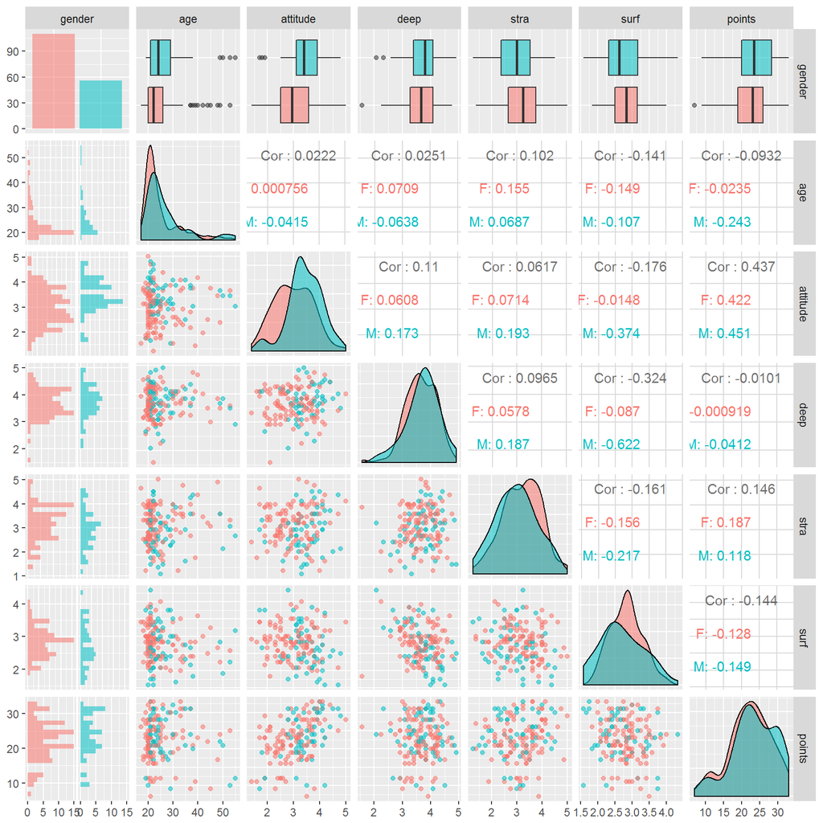

### 3. Multiple regression model - with three explanatory variables

#### Here I have chosen **attitude, strategic learning and deep learning** as my three explanatory variables, and **exam points** as the target variable. The summary as follow:

```
##
## Call:
## lm(formula = points ~ attitude + stra + deep, data = learning2014)
##
## Residuals:
##      Min       1Q   Median       3Q      Max
## -17.5239  -3.4276   0.5474   3.8220  11.5112
##
## Coefficients:
##             Estimate Std. Error t value Pr(>|t|)
## (Intercept)  11.3915     3.4077   3.343  0.00103 **
## attitude      3.5254     0.5683   6.203 4.44e-09 ***
## stra          0.9621     0.5367   1.793  0.07489 .
## deep         -0.7492     0.7507  -0.998  0.31974
## ---
## Signif. codes:  0 '***' 0.001 '**' 0.01 '*' 0.05 '.' 0.1 ' ' 1
##
## Residual standard error: 5.289 on 162 degrees of freedom
## Multiple R-squared:  0.2097, Adjusted R-squared:  0.195
## F-statistic: 14.33 on 3 and 162 DF,  p-value: 2.521e-08
```

#### The above summary shows that the multiple regression equation to be around

#### **points = 11.39 + 3.53(attitude) + 0.96(stra) - 0.75(deep)**

- if the value attitude increase by one, points will increase by 3.53 (if other variables stay the same), and so on. When all three explanatory variables are 0, points is predicted to be 11.39.(This may be because we have excluded points=0)
- From F test for overall significance, we can conclude that at least one explanatory variable affects ‘points’.
- The t test shows that there is evidence that ‘attitude’ affects ‘points’, however, it is also quite clear that ‘deep’ has no linear relationship with ‘points’.

### 4. Multiple regression model - remove deep from the previous model

```
##
## Call:
## lm(formula = points ~ attitude + stra, data = learning2014)
##
## Residuals:
##      Min       1Q   Median       3Q      Max
## -17.6436  -3.3113   0.5575   3.7928  10.9295
##
## Coefficients:
##             Estimate Std. Error t value Pr(>|t|)
## (Intercept)   8.9729     2.3959   3.745  0.00025 ***
## attitude      3.4658     0.5652   6.132 6.31e-09 ***
## stra          0.9137     0.5345   1.709  0.08927 .
## ---
## Signif. codes:  0 '***' 0.001 '**' 0.01 '*' 0.05 '.' 0.1 ' ' 1
##
## Residual standard error: 5.289 on 163 degrees of freedom
## Multiple R-squared:  0.2048, Adjusted R-squared:  0.1951
## F-statistic: 20.99 on 2 and 163 DF,  p-value: 7.734e-09
```

#### The new summary shows that the regression equation at about

#### **points = 8.97 + 3.47(attitude) + 0.91(stra)**

- Both the explanatory variables have positive affects on the target variable.
- Multiple R-squared here indicates that 20.5% of the variation in points is explained by the variation in attitude and stra.

### 5. Model validation

#### The linear regression model assumes that:

- Errors are normally distributed.
- Errors are not correlated.
- Errors have constant variance.
- The size of a given error does not depend on the explanatory variables

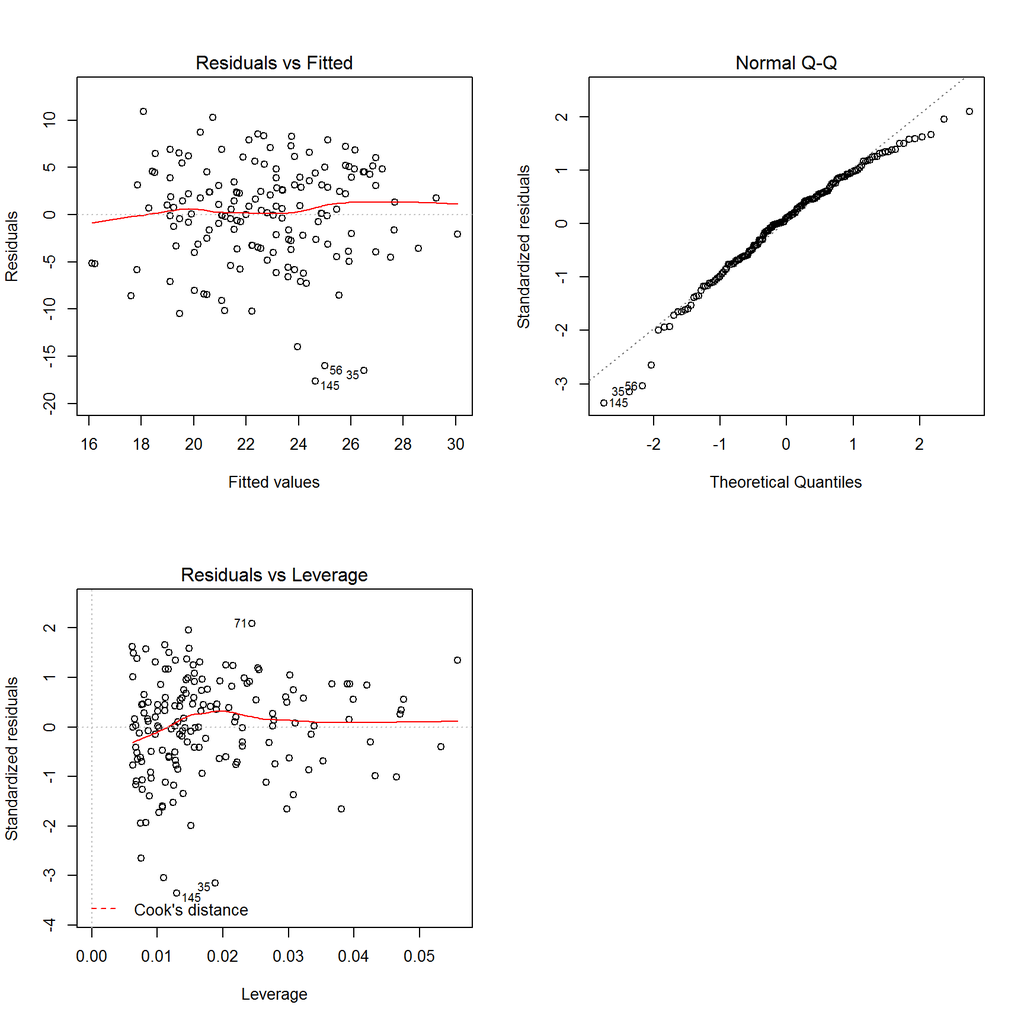

- The Residuals vs Fitted values plot here has no pattern, which supports the assumption of constant variance of errors and the size of the errors do not depend on the explanatory variables.
- The Normal QQ plot here shows that a resonable fit with the line, which means the errors are normally distributed. However, our model is less suitable in the both ends of values.
- The Residuals vs Leverage plot can measure how much impact a single observation has on the model. Here it is quite scattered, but all are withen 0.06, which means no outliers. (We have already eliminate the observations where points = 0)

### 6. Conclusion

#### Attitude has a linear relationship with exam points, but other variables do not have statistically significant relationship with points. What we can do is to find the simple linear regression where attitude is the explanatory variable and use the model to do points predictions in the future.

# Logistic Regression (week 3)

*This week we did data wrangling on two new data sets retrieved from the UCI Machine Learning Repository. The data are from two identical questionaires related to secondary school student alcohol comsumption in Portugal.* *We then perform analysis on the combined dataset*

#### Data set information: https://archive.ics.uci.edu/ml/datasets/STUDENT+ALCOHOL+CONSUMPTION

*P. Cortez and A. Silva. Using Data Mining to Predict Secondary School Student Performance. In A. Brito and J. Teixeira Eds., Proceedings of 5th FUture BUsiness TEChnology Conference (FUBUTEC 2008) pp. 5-12, Porto, Portugal, April, 2008, EUROSIS, ISBN 978-9077381-39-7.*

## 1. Data wrangling

*you can see it in my github:* https://github.com/tzsu/IODS-project/blob/master/data/create_alc.R

## 2. Analysis

### 1. Take a look at our new dataset

#### The following adjustments have been made:

- to The variables not used for joining the two data have been combined by averaging (including the grade variables)
- **alc_use** is the average of **Dalc** and **Walc**
- **high_use** is **TRUE** if alc_use is higher than 2 and FALSE otherwise. #### Some variables are numerical and some are not.

```
## Observations: 382
## Variables: 35
## $ school     <fctr> GP, GP, GP, GP, GP, GP, GP, GP, GP, GP, GP, GP, GP...
## $ sex        <fctr> F, F, F, F, F, M, M, F, M, M, F, F, M, M, M, F, F,...
## $ age        <int> 18, 17, 15, 15, 16, 16, 16, 17, 15, 15, 15, 15, 15,...
## $ address    <fctr> U, U, U, U, U, U, U, U, U, U, U, U, U, U, U, U, U,...
## $ famsize    <fctr> GT3, GT3, LE3, GT3, GT3, LE3, LE3, GT3, LE3, GT3, ...
## $ Pstatus    <fctr> A, T, T, T, T, T, T, A, A, T, T, T, T, T, A, T, T,...
## $ Medu       <int> 4, 1, 1, 4, 3, 4, 2, 4, 3, 3, 4, 2, 4, 4, 2, 4, 4, ...
## $ Fedu       <int> 4, 1, 1, 2, 3, 3, 2, 4, 2, 4, 4, 1, 4, 3, 2, 4, 4, ...
## $ Mjob       <fctr> at_home, at_home, at_home, health, other, services...
## $ Fjob       <fctr> teacher, other, other, services, other, other, oth...
## $ reason     <fctr> course, course, other, home, home, reputation, hom...
## $ nursery    <fctr> yes, no, yes, yes, yes, yes, yes, yes, yes, yes, y...
## $ internet   <fctr> no, yes, yes, yes, no, yes, yes, no, yes, yes, yes...
```

[output cut: 22 more lines]

### 2. Explore relationships between alcohol consumption and other variables

#### Here I have chosen 4 variables and with each of them, the following are my hypotheses based on personal experience. I am eager to know if my assumptions are true or not.

- Students who have better grades in the final drink less alcohol. (**G3**)
- Students who have more school absences drinks more. (**absences**)
- Students with more freetimes will consume more alcohol.(**freetime**)
- Those who are in a relationship will drink more. (**romantic**)

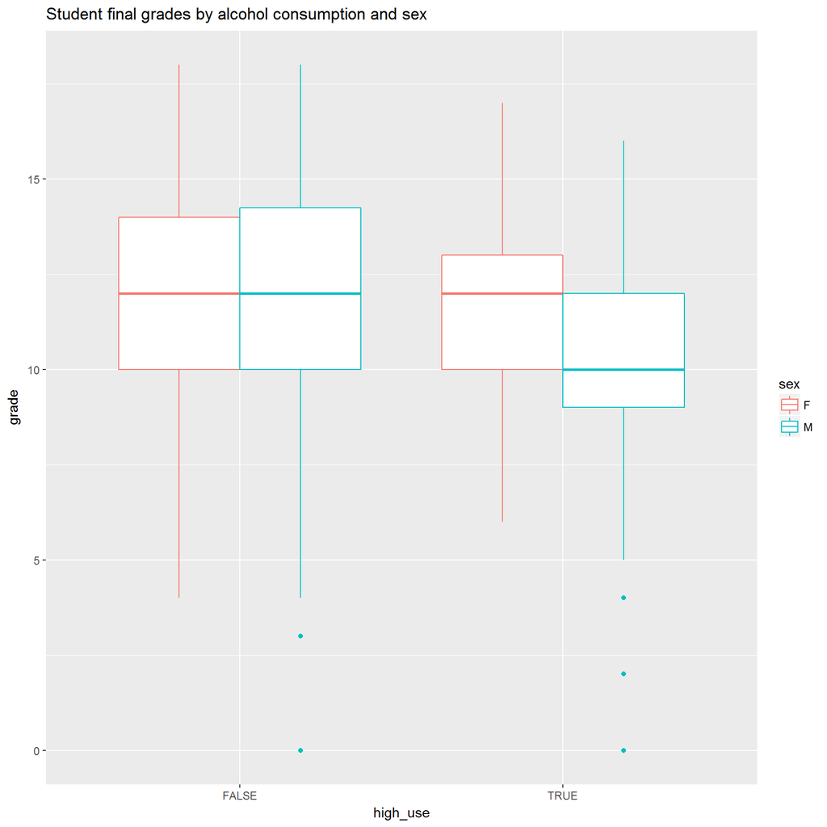

```r
# initialize a plot of high_use and G3
g1 <- ggplot(alc, aes(x = high_use, y = G3, col=sex)) + geom_boxplot() + ylab('final grade') + xlab('high_use')
# define the plot as a boxplot and draw it
g1 + geom_boxplot() + ylab("grade")+ ggtitle("Student final grades by alcohol consumption and sex")
```

#### Graph 1 does not seem to support my assumption perfectly. Grade and alcohol consumption are not correlated within the girls group, however, boys who drink more tend to have poorer grades.

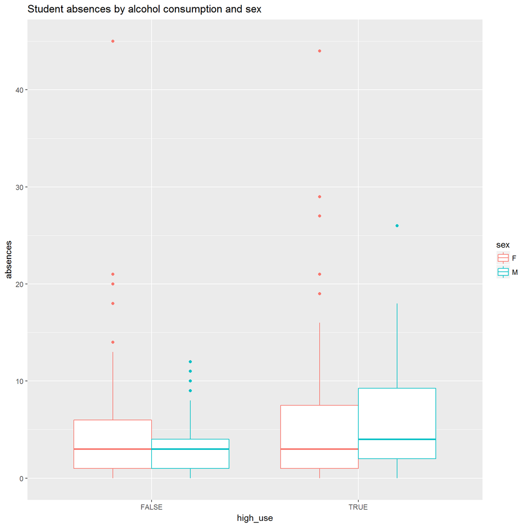

```r
# initialise a plot of high_use and absences
g2 <- ggplot(alc, aes(x= high_use, y = absences, col = sex))
# define the plot as a boxplot and draw it
g2 +geom_boxplot() + ggtitle("Student absences by alcohol consumption and sex")
```

#### Graph 2 seems to support my assumption that students who were absence from school more times will drink more.

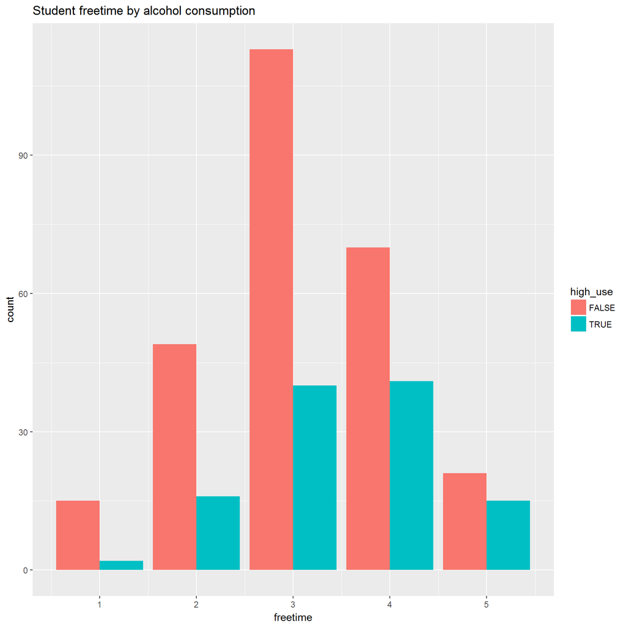

#### Graph 3 (although this graph may be hard to read), seems to support my hypothesis. There is a higher percentage of high_use when there is more freetime.

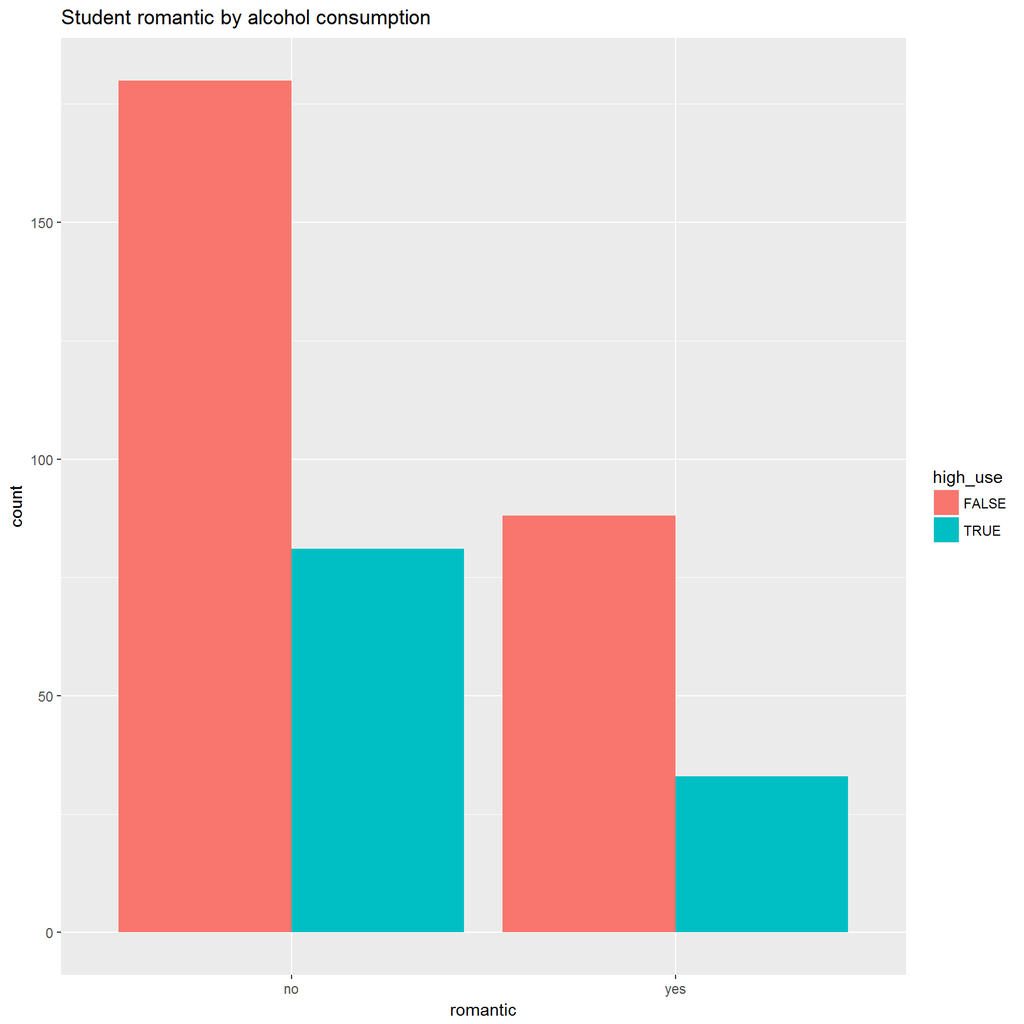

#### Graph 4 does not support my hypothesis. It even looks like the opposite of my assumption. There is a bigger percentage of “high_use” within the people who is not in a relationship.

### 3. Logistic regression

```
##
## Call:
## glm(formula = high_use ~ G3 + absences + freetime + romantic,
##     family = "binomial", data = alc)
##
## Deviance Residuals:
##     Min       1Q   Median       3Q      Max
## -1.9530  -0.8385  -0.6665   1.1801   1.9643
##
## Coefficients:
##             Estimate Std. Error z value Pr(>|z|)
## (Intercept) -1.51913    0.60984  -2.491  0.01274 *
## G3          -0.07804    0.03593  -2.172  0.02985 *
## absences     0.09021    0.02273   3.969 7.22e-05 ***
## freetime     0.37457    0.12303   3.044  0.00233 **
## romanticyes -0.38846    0.26103  -1.488  0.13670
## ---
## Signif. codes:  0 '***' 0.001 '**' 0.01 '*' 0.05 '.' 0.1 ' ' 1
##
## (Dispersion parameter for binomial family taken to be 1)
##
##     Null deviance: 465.68  on 381  degrees of freedom
## Residual deviance: 431.27  on 377  degrees of freedom
## AIC: 441.27
##
## Number of Fisher Scoring iterations: 4
```

#### Now I take out the variables grade and romantic, and fit the model again

```
##
## Call:
## glm(formula = high_use ~ absences + freetime, family = "binomial",
##     data = alc)
##
## Deviance Residuals:
##     Min       1Q   Median       3Q      Max
## -2.0492  -0.8434  -0.6919   1.1776   1.9269
##
## Coefficients:
##             Estimate Std. Error z value Pr(>|z|)
## (Intercept) -2.51574    0.44500  -5.653 1.57e-08 ***
## absences     0.09139    0.02276   4.015 5.94e-05 ***
## freetime     0.37222    0.12176   3.057  0.00223 **
## ---
## Signif. codes:  0 '***' 0.001 '**' 0.01 '*' 0.05 '.' 0.1 ' ' 1
##
## (Dispersion parameter for binomial family taken to be 1)
##
##     Null deviance: 465.68  on 381  degrees of freedom
## Residual deviance: 437.70  on 379  degrees of freedom
## AIC: 443.7
##
## Number of Fisher Scoring iterations: 4
```

### 4. Predictions

```
##         prediction
## high_use FALSE TRUE
##    FALSE   258   10
##    TRUE     96   18
```

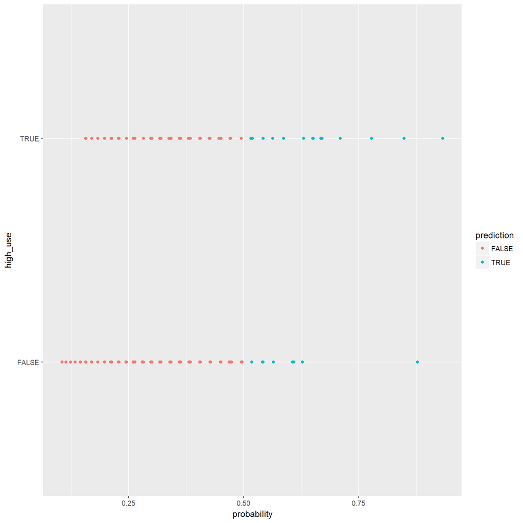

```
##         prediction
## high_use      FALSE       TRUE        Sum
##    FALSE 0.67539267 0.02617801 0.70157068
##    TRUE  0.25130890 0.04712042 0.29842932
##    Sum   0.92670157 0.07329843 1.00000000
```

```r
# define a loss function (mean prediction error)
loss_func <- function(class, prob) {
  n_wrong <- abs(class - prob) > 0.5
  mean(n_wrong)
}

# call loss_func to compute the average number of wrong predictions in the (training) data
loss_func(class = alc$high_use, prob = alc$probability)
```

```
## [1] 0.2774869
```

# Clustering and Classification (week 4)

*This week we will look at the dataset, “Boston”, which already exists inside R, and perform clustering and classification on the data. Also, data wrangling for next week deals with two datasets, “Human development” and “Gender inequality”.*

## 1. Data wrangling for next week

*you can see it in my github:* https://github.com/tzsu/IODS-project/blob/master/data/create_human.R

## 2. Analysis

### 1. about the data: Housing Values in Suburbs of Boston

#### It is from two sources

- 1. Harrison, D. and Rubinfeld, D.L. (1978) Hedonic prices and the demand for clean air. J. Environ. Economics and Management 5, 81–102.
- 2. Belsley D.A., Kuh, E. and Welsch, R.E. (1980) Regression Diagnostics. Identifying Influential Data and Sources of Collinearity. New York: Wiley.

#### The Boston data frame has 506 observations and 14 variables. The following are the variables:

- **crim** - per capita crime rate by town
- **zn** - proportion of residential land zoned for lots over 25,000 sq.ft
- **indus** - proportion of non-retail business acres per town
- **chas** - Charles River dummy variable (= 1 if tract bounds river; 0 otherwise)
- **nox** - nitrogen oxides concentration (parts per 10 million)
- **rm** - average number of rooms per dwelling
- **age** - proportion of owner-occupied units built prior to 1940
- **dis** - weighted mean of distances to five Boston employment centres
- **rad** - index of accessibility to radial highways
- **tax** - full-value property-tax rate per $10,000
- **ptratio** - pupil-teacher ratio by town
- **black** - 1000(Bk - 0.63)^2 where Bk is the proportion of blacks by town
- **lstat** - lower status of the population (%)
- **medv** - median value of owner-occupied homes in $1000s

```r
# load the data
data("Boston")
# explore the dataset
str(Boston)
```

```
## 'data.frame':    506 obs. of  14 variables:
##  $ crim   : num  0.00632 0.02731 0.02729 0.03237 0.06905 ...
##  $ zn     : num  18 0 0 0 0 0 12.5 12.5 12.5 12.5 ...
##  $ indus  : num  2.31 7.07 7.07 2.18 2.18 2.18 7.87 7.87 7.87 7.87 ...
##  $ chas   : int  0 0 0 0 0 0 0 0 0 0 ...
##  $ nox    : num  0.538 0.469 0.469 0.458 0.458 0.458 0.524 0.524 0.524 0.524 ...
##  $ rm     : num  6.58 6.42 7.18 7 7.15 ...
##  $ age    : num  65.2 78.9 61.1 45.8 54.2 58.7 66.6 96.1 100 85.9 ...
##  $ dis    : num  4.09 4.97 4.97 6.06 6.06 ...
##  $ rad    : int  1 2 2 3 3 3 5 5 5 5 ...
##  $ tax    : num  296 242 242 222 222 222 311 311 311 311 ...
##  $ ptratio: num  15.3 17.8 17.8 18.7 18.7 18.7 15.2 15.2 15.2 15.2 ...
##  $ black  : num  397 397 393 395 397 ...
##  $ lstat  : num  4.98 9.14 4.03 2.94 5.33 ...
##  $ medv   : num  24 21.6 34.7 33.4 36.2 28.7 22.9 27.1 16.5 18.9 ...
```

```r
summary(Boston)
```

```
##       crim                zn             indus            chas
##  Min.   : 0.00632   Min.   :  0.00   Min.   : 0.46   Min.   :0.00000
##  1st Qu.: 0.08204   1st Qu.:  0.00   1st Qu.: 5.19   1st Qu.:0.00000
##  Median : 0.25651   Median :  0.00   Median : 9.69   Median :0.00000
##  Mean   : 3.61352   Mean   : 11.36   Mean   :11.14   Mean   :0.06917
##  3rd Qu.: 3.67708   3rd Qu.: 12.50   3rd Qu.:18.10   3rd Qu.:0.00000
##  Max.   :88.97620   Max.   :100.00   Max.   :27.74   Max.   :1.00000
##       nox               rm             age              dis
##  Min.   :0.3850   Min.   :3.561   Min.   :  2.90   Min.   : 1.130
##  1st Qu.:0.4490   1st Qu.:5.886   1st Qu.: 45.02   1st Qu.: 2.100
##  Median :0.5380   Median :6.208   Median : 77.50   Median : 3.207
##  Mean   :0.5547   Mean   :6.285   Mean   : 68.57   Mean   : 3.795
##  3rd Qu.:0.6240   3rd Qu.:6.623   3rd Qu.: 94.08   3rd Qu.: 5.188
##  Max.   :0.8710   Max.   :8.780   Max.   :100.00   Max.   :12.127
##       rad              tax           ptratio          black
##  Min.   : 1.000   Min.   :187.0   Min.   :12.60   Min.   :  0.32
##  1st Qu.: 4.000   1st Qu.:279.0   1st Qu.:17.40   1st Qu.:375.38
##  Median : 5.000   Median :330.0   Median :19.05   Median :391.44
##  Mean   : 9.549   Mean   :408.2   Mean   :18.46   Mean   :356.67
##  3rd Qu.:24.000   3rd Qu.:666.0   3rd Qu.:20.20   3rd Qu.:396.23
##  Max.   :24.000   Max.   :711.0   Max.   :22.00   Max.   :396.90
##      lstat            medv
##  Min.   : 1.73   Min.   : 5.00
##  1st Qu.: 6.95   1st Qu.:17.02
##  Median :11.36   Median :21.20
##  Mean   :12.65   Mean   :22.53
##  3rd Qu.:16.95   3rd Qu.:25.00
##  Max.   :37.97   Max.   :50.00
```

### 2. Visualising the data

#### Pairing up all the variables cannot really show anything to us. I tried accessing library(corrplot), but the package cannot be downloaded by my r version :(

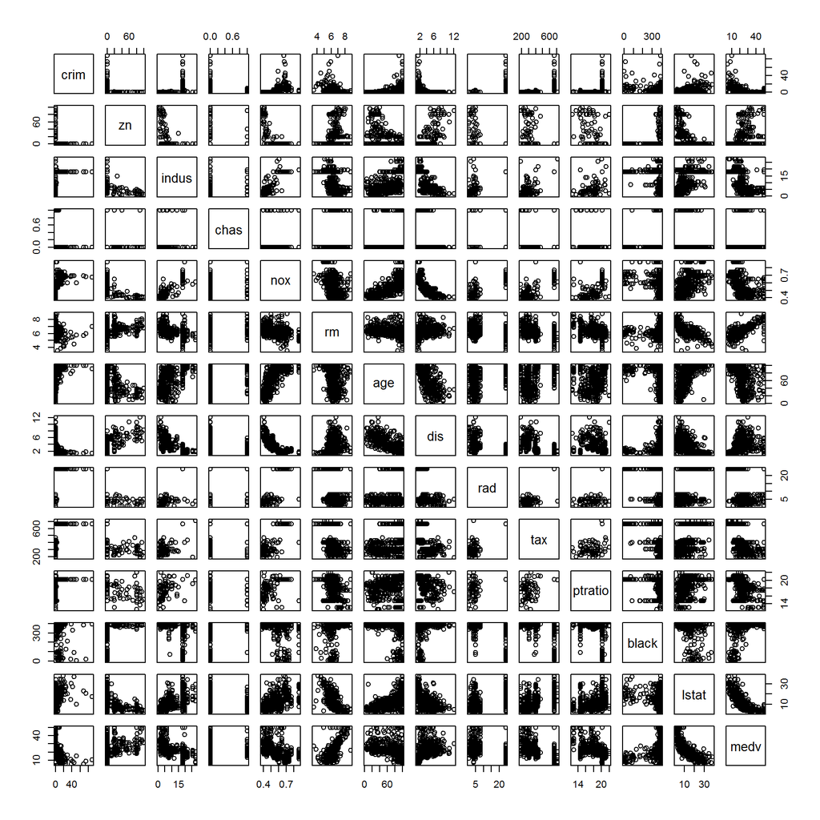

```r
# plot matrix of the variables
pairs(Boston)
```

```r
# calculate the correlation matrix and round it
cor_matrix<-cor(Boston)%>%round(2)
# print the correlation matrix
cor_matrix
```

```
##          crim    zn indus  chas   nox    rm   age   dis   rad   tax
## crim     1.00 -0.20  0.41 -0.06  0.42 -0.22  0.35 -0.38  0.63  0.58
## zn      -0.20  1.00 -0.53 -0.04 -0.52  0.31 -0.57  0.66 -0.31 -0.31
## indus    0.41 -0.53  1.00  0.06  0.76 -0.39  0.64 -0.71  0.60  0.72
## chas    -0.06 -0.04  0.06  1.00  0.09  0.09  0.09 -0.10 -0.01 -0.04
## nox      0.42 -0.52  0.76  0.09  1.00 -0.30  0.73 -0.77  0.61  0.67
## rm      -0.22  0.31 -0.39  0.09 -0.30  1.00 -0.24  0.21 -0.21 -0.29
## age      0.35 -0.57  0.64  0.09  0.73 -0.24  1.00 -0.75  0.46  0.51
## dis     -0.38  0.66 -0.71 -0.10 -0.77  0.21 -0.75  1.00 -0.49 -0.53
## rad      0.63 -0.31  0.60 -0.01  0.61 -0.21  0.46 -0.49  1.00  0.91
## tax      0.58 -0.31  0.72 -0.04  0.67 -0.29  0.51 -0.53  0.91  1.00
## ptratio  0.29 -0.39  0.38 -0.12  0.19 -0.36  0.26 -0.23  0.46  0.46
## black   -0.39  0.18 -0.36  0.05 -0.38  0.13 -0.27  0.29 -0.44 -0.44
## lstat    0.46 -0.41  0.60 -0.05  0.59 -0.61  0.60 -0.50  0.49  0.54
## medv    -0.39  0.36 -0.48  0.18 -0.43  0.70 -0.38  0.25 -0.38 -0.47
##         ptratio black lstat  medv
## crim       0.29 -0.39  0.46 -0.39
## zn        -0.39  0.18 -0.41  0.36
## indus      0.38 -0.36  0.60 -0.48
## chas      -0.12  0.05 -0.05  0.18
## nox        0.19 -0.38  0.59 -0.43
## rm        -0.36  0.13 -0.61  0.70
## age        0.26 -0.27  0.60 -0.38
## dis       -0.23  0.29 -0.50  0.25
## rad        0.46 -0.44  0.49 -0.38
## tax        0.46 -0.44  0.54 -0.47
## ptratio    1.00 -0.18  0.37 -0.51
## black     -0.18  1.00 -0.37  0.33
## lstat      0.37 -0.37  1.00 -0.74
## medv      -0.51  0.33 -0.74  1.00
```

### 3. Standardizing the dataset

#### Standardizing the data we subtract the column means from the corresponding columns and divide the difference with standard deviation. The means of the variables will then all become zero.

```r
# center and standardize variables
boston_scaled <- scale(Boston)
# summaries of the scaled variables
summary(boston_scaled)
```

```
##       crim                 zn               indus
##  Min.   :-0.419367   Min.   :-0.48724   Min.   :-1.5563
##  1st Qu.:-0.410563   1st Qu.:-0.48724   1st Qu.:-0.8668
##  Median :-0.390280   Median :-0.48724   Median :-0.2109
##  Mean   : 0.000000   Mean   : 0.00000   Mean   : 0.0000
##  3rd Qu.: 0.007389   3rd Qu.: 0.04872   3rd Qu.: 1.0150
##  Max.   : 9.924110   Max.   : 3.80047   Max.   : 2.4202
##       chas              nox                rm               age
##  Min.   :-0.2723   Min.   :-1.4644   Min.   :-3.8764   Min.   :-2.3331
##  1st Qu.:-0.2723   1st Qu.:-0.9121   1st Qu.:-0.5681   1st Qu.:-0.8366
##  Median :-0.2723   Median :-0.1441   Median :-0.1084   Median : 0.3171
##  Mean   : 0.0000   Mean   : 0.0000   Mean   : 0.0000   Mean   : 0.0000
##  3rd Qu.:-0.2723   3rd Qu.: 0.5981   3rd Qu.: 0.4823   3rd Qu.: 0.9059
##  Max.   : 3.6648   Max.   : 2.7296   Max.   : 3.5515   Max.   : 1.1164
##       dis               rad               tax             ptratio
##  Min.   :-1.2658   Min.   :-0.9819   Min.   :-1.3127   Min.   :-2.7047
##  1st Qu.:-0.8049   1st Qu.:-0.6373   1st Qu.:-0.7668   1st Qu.:-0.4876
##  Median :-0.2790   Median :-0.5225   Median :-0.4642   Median : 0.2746
##  Mean   : 0.0000   Mean   : 0.0000   Mean   : 0.0000   Mean   : 0.0000
##  3rd Qu.: 0.6617   3rd Qu.: 1.6596   3rd Qu.: 1.5294   3rd Qu.: 0.8058
##  Max.   : 3.9566   Max.   : 1.6596   Max.   : 1.7964   Max.   : 1.6372
##      black             lstat              medv
##  Min.   :-3.9033   Min.   :-1.5296   Min.   :-1.9063
##  1st Qu.: 0.2049   1st Qu.:-0.7986   1st Qu.:-0.5989
##  Median : 0.3808   Median :-0.1811   Median :-0.1449
##  Mean   : 0.0000   Mean   : 0.0000   Mean   : 0.0000
##  3rd Qu.: 0.4332   3rd Qu.: 0.6024   3rd Qu.: 0.2683
##  Max.   : 0.4406   Max.   : 3.5453   Max.   : 2.9865
```

```r
# class of the boston_scaled object
class(boston_scaled)
```

```
## [1] "matrix"
```

```r
# change the object to data frame
boston_scaled <- as.data.frame(boston_scaled)
```

#### Now create a categorical variable of the crime rate, and use the quantiles as the break points in the categorical variables. Then drop the old crime rate variable from the dataset. Divide the dataset to train and test sets, so that 80% of the data belongs to the train set.

```
##      Min.   1st Qu.    Median      Mean   3rd Qu.      Max.
## -0.419400 -0.410600 -0.390300  0.000000  0.007389  9.924000
```

```
##           0%          25%          50%          75%         100%
## -0.419366929 -0.410563278 -0.390280295  0.007389247  9.924109610
```

```
## < table of extent 0 >
```

```
## [1] 506
```

### 4. Fitting the linear discriminant analysis on the train set. Use the categorical crime rate as the target variable and all the other variables in the dataset as predictor variables.

```r
# linear discriminant analysis
lda.fit <- lda(crime~., data = train)
# the function for lda biplot arrows
lda.arrows <- function(x, myscale = 1, arrow_heads = 0.1, color = "red", tex = 0.75, choices = c(1,2)){
  heads <- coef(x)
  arrows(x0 = 0, y0 = 0,
         x1 = myscale * heads[,choices[1]],
         y1 = myscale * heads[,choices[2]], col=color, length = arrow_heads)
  text(myscale * heads[,choices], labels = row.names(heads),
       cex = tex, col=color, pos=3)
}
# target classes as numeric
classes <- as.numeric(train$crime)
```

#### Look at the LDA (bi)plot.

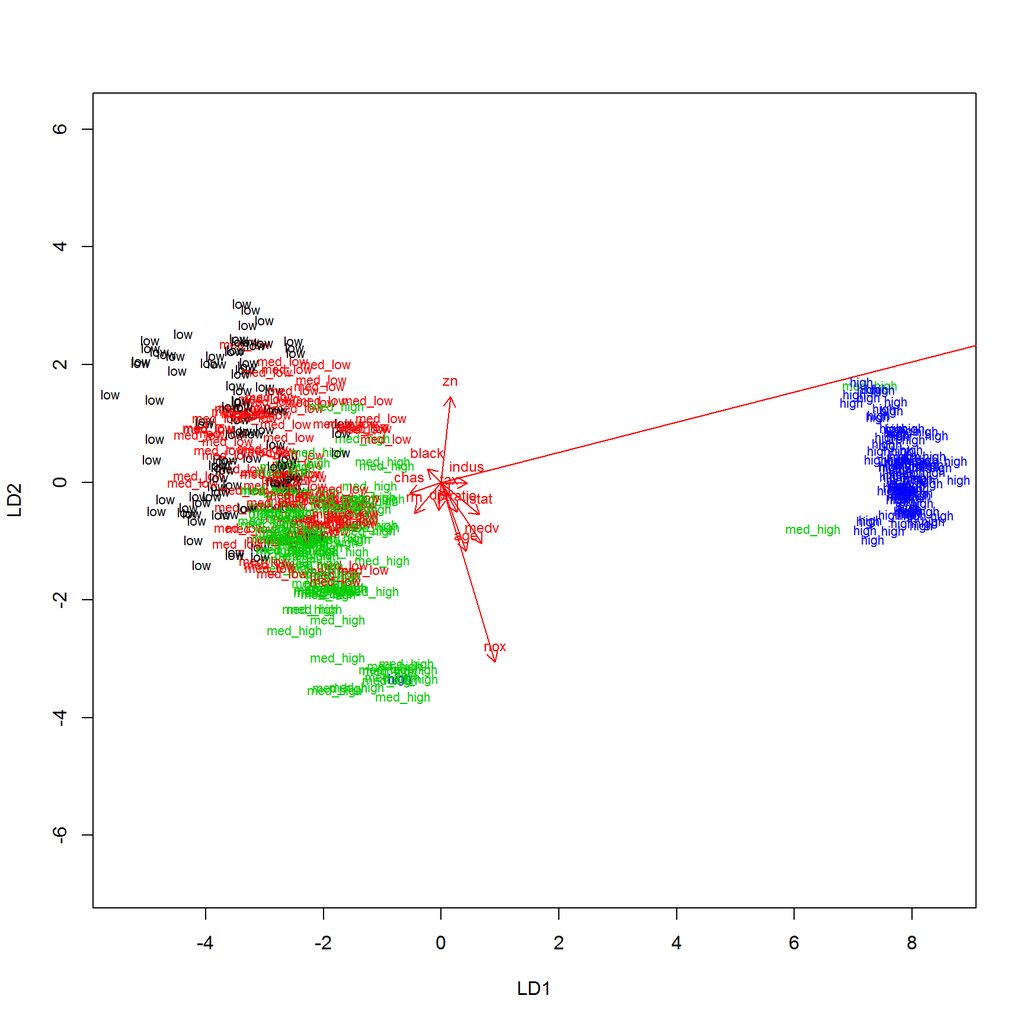

```r
# plot the lda results
plot(lda.fit, dimen = 2, col = classes, pch = classes)
lda.arrows(lda.fit, myscale = 3)
```

### 5. Predicting

#### The results show that the classifier predict the crime rates quite correctly.

```r
# predict classes with test data
lda.pred <- predict(lda.fit, newdata = test)

# cross tabulate the results
table(correct = correct_classes, predicted = lda.pred$class)
```

```
##           predicted
## correct    low med_low med_high high
##   low       20       5        1    0
##   med_low    5      17        4    0
##   med_high   1      10       13    4
##   high       0       0        0   22
```

# Dimensionality reduction techniques (week 5)

*This week we first continue with human data wrangling from last week, and then analysize the data using dimensionality reduction techniques.*

## 1. Data wrangling continuing from last week

*you can see it in my github:* https://github.com/tzsu/IODS-project/blob/master/data/create_human.R

## 2. Analysis

### 1. About the Human data:

*The Human data includes two data sets: “Human development” and “Gender inequality”. We keep only the countries in both data sets, and exclude rows with missing values . After combining some variables and excluding some, the **Human** data we will use for performing analysis has 155 observations and the folowing 8 variables:*

#### the 8 variables:

- ratioedu2.fm = Share of female population with secondary education over(/) share of male population with secondary education
- ratiolab.fm = Share of female population that participates in labour force over(/) share of male population that participates in labour force
- exp.y.edu = Expected years of schooling
- life.exp = Life expectancy at birth
- gni.cap = Gross national income per capita
- mmr = Maternal mortality ratio
- ad.b.r = Adolescent birth rate
- par% = population with at least some secondary education

```r
#set wokring directory and load the human data into R

setwd("D:/Sydney Uni/forth semester units of study/Intro to Open Data Science/IODS-project")

human <- as.data.frame(read.table('data/human.csv', sep="\t", header = TRUE))
```

```r
#explore the structure and dimentions of the data
str(human)
```

```
## 'data.frame':    155 obs. of  8 variables:
##  $ ratioedu2.fm: num  1.007 0.997 0.983 0.989 0.969 ...
##  $ ratiolab.fm : num  0.891 0.819 0.825 0.884 0.829 ...
##  $ exp.y.edu   : num  17.5 20.2 15.8 18.7 17.9 16.5 18.6 16.5 15.9 19.2 ...
##  $ life.exp    : num  81.6 82.4 83 80.2 81.6 80.9 80.9 79.1 82 81.8 ...
##  $ gni.cap     : int  64992 42261 56431 44025 45435 43919 39568 52947 42155 32689 ...
##  $ mmr         : int  4 6 6 5 6 7 9 28 11 8 ...
##  $ ad.b.r      : num  7.8 12.1 1.9 5.1 6.2 3.8 8.2 31 14.5 25.3 ...
##  $ par.        : num  39.6 30.5 28.5 38 36.9 36.9 19.9 19.4 28.2 31.4 ...
```

### 2. Graphical overview and interpretation

#### From the graph below we can see that “gni.cap”, “mmr”, and “ad.b.r” are right skewed, whereas, “exp.y.edu” is close to normal distribution. “exp.y.edu”(expected year of education) and “life.exp”(life expectancy at birth) seems to be correlated.

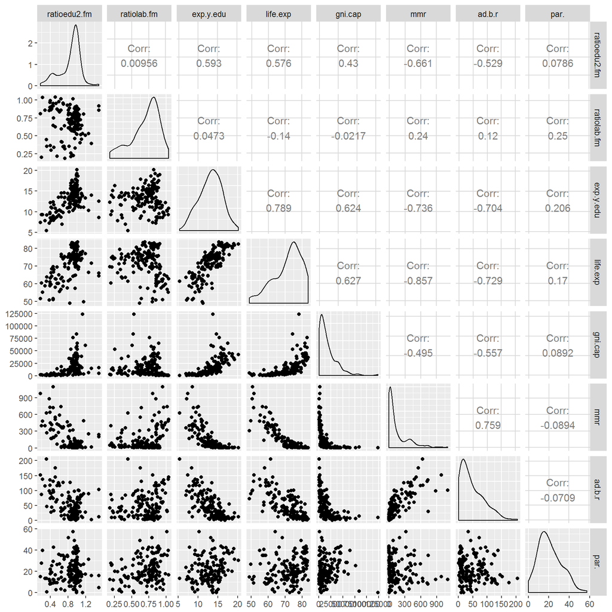

```r
ggpairs(human)
```

```r
summary(human)
```

```
##   ratioedu2.fm     ratiolab.fm       exp.y.edu        life.exp
##  Min.   :0.1717   Min.   :0.1857   Min.   : 5.40   Min.   :49.00
##  1st Qu.:0.7264   1st Qu.:0.5984   1st Qu.:11.25   1st Qu.:66.30
##  Median :0.9375   Median :0.7535   Median :13.50   Median :74.20
##  Mean   :0.8529   Mean   :0.7074   Mean   :13.18   Mean   :71.65
##  3rd Qu.:0.9968   3rd Qu.:0.8535   3rd Qu.:15.20   3rd Qu.:77.25
##  Max.   :1.4967   Max.   :1.0380   Max.   :20.20   Max.   :83.50
##     gni.cap            mmr             ad.b.r            par.
##  Min.   :   581   Min.   :   1.0   Min.   :  0.60   Min.   : 0.00
##  1st Qu.:  4198   1st Qu.:  11.5   1st Qu.: 12.65   1st Qu.:12.40
##  Median : 12040   Median :  49.0   Median : 33.60   Median :19.30
##  Mean   : 17628   Mean   : 149.1   Mean   : 47.16   Mean   :20.91
##  3rd Qu.: 24512   3rd Qu.: 190.0   3rd Qu.: 71.95   3rd Qu.:27.95
##  Max.   :123124   Max.   :1100.0   Max.   :204.80   Max.   :57.50
```

### 3. PCA (principal component analysis)

```r
#perform pca
pca_human <- prcomp(human)
#show summary of the non-standardized variables
summary(pca_human)
```

```
## Importance of components:
##                              PC1      PC2   PC3   PC4   PC5   PC6    PC7
## Standard deviation     1.854e+04 185.5219 25.19 11.45 3.766 1.566 0.1912
## Proportion of Variance 9.999e-01   0.0001  0.00  0.00 0.000 0.000 0.0000
## Cumulative Proportion  9.999e-01   1.0000  1.00  1.00 1.000 1.000 1.0000
##                           PC8
## Standard deviation     0.1591
## Proportion of Variance 0.0000
## Cumulative Proportion  1.0000
```

```r
#draw a biplot of the principal component
```

[output not shown]

#### **Standardized**: The means of every variables will become 0. I don’t really understand this part…

```r
# standardize human data
human_std <- scale(human)

# print out summaries of the standardized variables
summary(human_std)
```

```
##   ratioedu2.fm      ratiolab.fm        exp.y.edu          life.exp
##  Min.   :-2.8189   Min.   :-2.6247   Min.   :-2.7378   Min.   :-2.7188
##  1st Qu.:-0.5233   1st Qu.:-0.5484   1st Qu.:-0.6782   1st Qu.:-0.6425
##  Median : 0.3503   Median : 0.2316   Median : 0.1140   Median : 0.3056
##  Mean   : 0.0000   Mean   : 0.0000   Mean   : 0.0000   Mean   : 0.0000
##  3rd Qu.: 0.5958   3rd Qu.: 0.7350   3rd Qu.: 0.7126   3rd Qu.: 0.6717
##  Max.   : 2.6646   Max.   : 1.6632   Max.   : 2.4730   Max.   : 1.4218
##     gni.cap             mmr              ad.b.r             par.
##  Min.   :-0.9193   Min.   :-0.6992   Min.   :-1.1325   Min.   :-1.8203
##  1st Qu.:-0.7243   1st Qu.:-0.6496   1st Qu.:-0.8394   1st Qu.:-0.7409
##  Median :-0.3013   Median :-0.4726   Median :-0.3298   Median :-0.1403
##  Mean   : 0.0000   Mean   : 0.0000   Mean   : 0.0000   Mean   : 0.0000
##  3rd Qu.: 0.3712   3rd Qu.: 0.1932   3rd Qu.: 0.6030   3rd Qu.: 0.6127
##  Max.   : 5.6890   Max.   : 4.4899   Max.   : 3.8344   Max.   : 3.1850
```

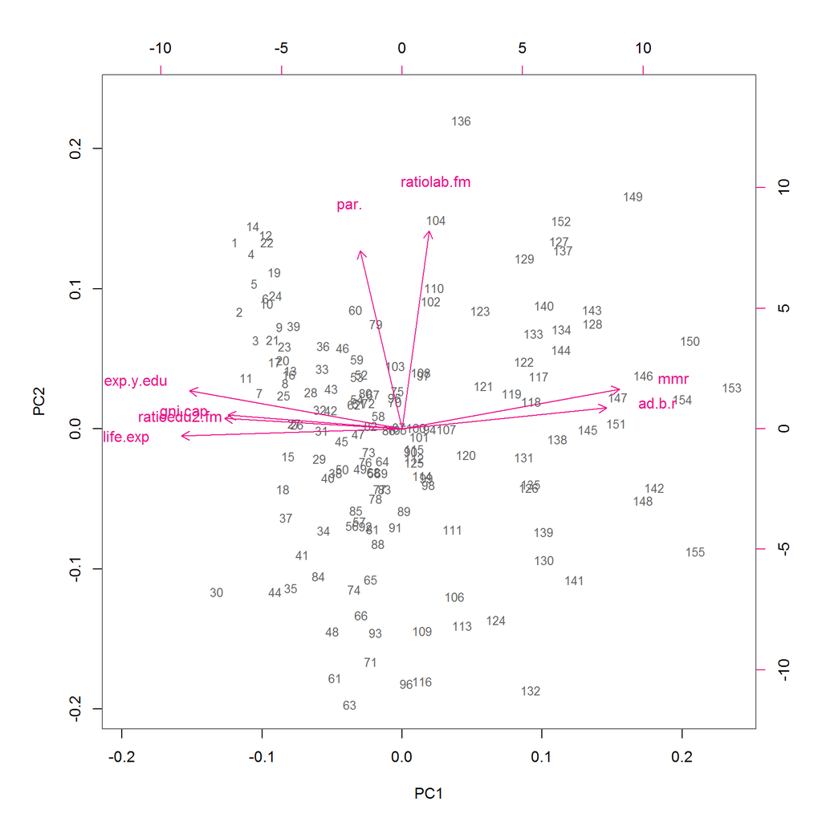

```r
# perform principal component analysis (with the SVD method)
pca_human <- prcomp(human_std)

# draw a biplot of the principal component representation and the original variables
biplot(pca_human, choices = 1:2, cex = c(0.8, 1), col = c("grey40", "deeppink2"))
```

## 4. It’s tea time

```r
#load tea data to R and glimpse it
data("tea")
glimpse(tea)
```

```
## Observations: 300
## Variables: 36
## $ breakfast        <fctr> breakfast, breakfast, Not.breakfast, Not.bre...
## $ tea.time         <fctr> Not.tea time, Not.tea time, tea time, Not.te...
## $ evening          <fctr> Not.evening, Not.evening, evening, Not.eveni...
## $ lunch            <fctr> Not.lunch, Not.lunch, Not.lunch, Not.lunch, ...
## $ dinner           <fctr> Not.dinner, Not.dinner, dinner, dinner, Not....
## $ always           <fctr> Not.always, Not.always, Not.always, Not.alwa...
## $ home             <fctr> home, home, home, home, home, home, home, ho...
## $ work             <fctr> Not.work, Not.work, work, Not.work, Not.work...
## $ tearoom          <fctr> Not.tearoom, Not.tearoom, Not.tearoom, Not.t...
## $ friends          <fctr> Not.friends, Not.friends, friends, Not.frien...
## $ resto            <fctr> Not.resto, Not.resto, resto, Not.resto, Not....
## $ pub              <fctr> Not.pub, Not.pub, Not.pub, Not.pub, Not.pub,...
## $ Tea              <fctr> black, black, Earl Grey, Earl Grey, Earl Gre...
```

[output cut: 23 more lines]

```r
# column names to keep in the dataset
keep_columns <- c("Tea", "How", "how", "sugar", "where", "lunch")

# select the 'keep_columns' to create a new dataset
tea_time <- dplyr::select(tea, one_of(keep_columns))

# look at the summaries and structure of the data
summary(tea_time)
```

```
##         Tea         How                      how           sugar
##  black    : 74   alone:195   tea bag           :170   No.sugar:155
##  Earl Grey:193   lemon: 33   tea bag+unpackaged: 94   sugar   :145
##  green    : 33   milk : 63   unpackaged        : 36
##                  other:  9
##                   where           lunch
##  chain store         :192   lunch    : 44
##  chain store+tea shop: 78   Not.lunch:256
##  tea shop            : 30
##
```

```r
str(tea_time)
```

```
## 'data.frame':    300 obs. of  6 variables:
##  $ Tea  : Factor w/ 3 levels "black","Earl Grey",..: 1 1 2 2 2 2 2 1 2 1 ...
##  $ How  : Factor w/ 4 levels "alone","lemon",..: 1 3 1 1 1 1 1 3 3 1 ...
##  $ how  : Factor w/ 3 levels "tea bag","tea bag+unpackaged",..: 1 1 1 1 1 1 1 1 2 2 ...
##  $ sugar: Factor w/ 2 levels "No.sugar","sugar": 2 1 1 2 1 1 1 1 1 1 ...
##  $ where: Factor w/ 3 levels "chain store",..: 1 1 1 1 1 1 1 1 2 2 ...
##  $ lunch: Factor w/ 2 levels "lunch","Not.lunch": 2 2 2 2 2 2 2 2 2 2 ...
```

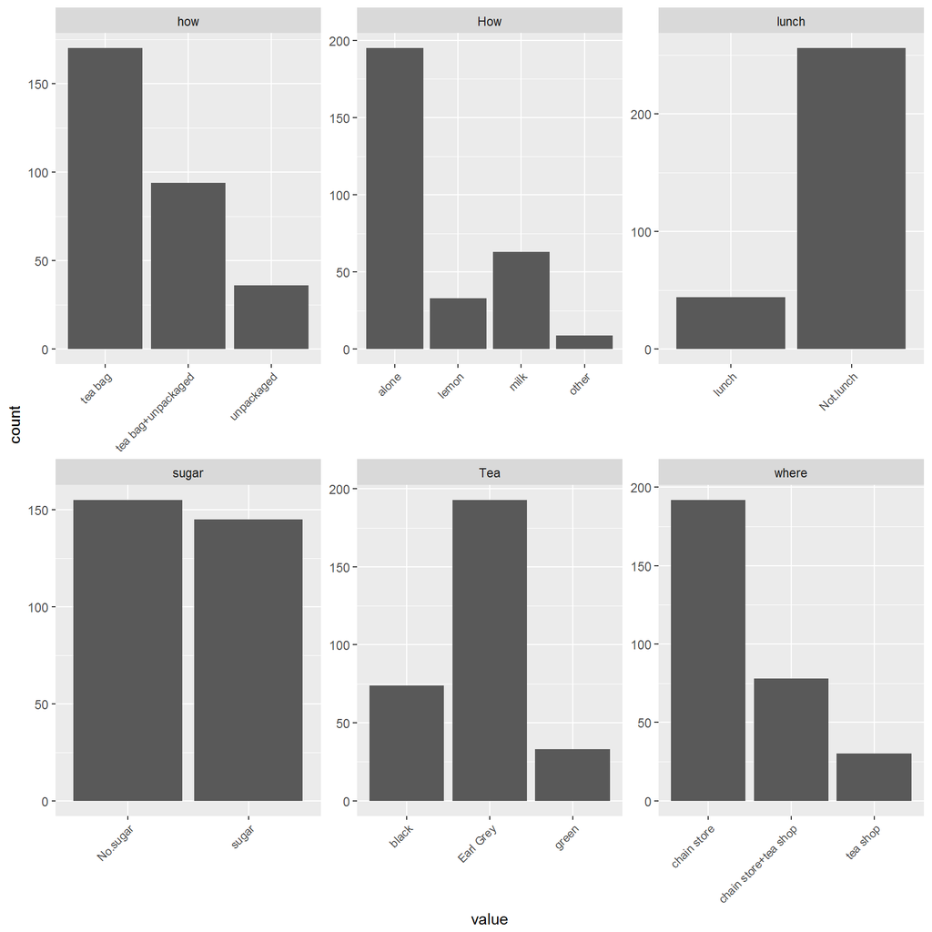

```r
# visualize the dataset
gather(tea_time) %>% ggplot(aes(value)) + facet_wrap("key", scales = "free") + geom_bar() + theme(axis.text.x = element_text(angle = 45, hjust = 1, size = 8))
```